# Modern Data Mining, HW 1

Wendy Deng

Ruolan Li

Kira Nightingale

Due: 11:59PM, Jan. 29th, 2023

# 1 Overview

This is a fast-paced course that covers a lot of material. There will be a large amount of references. You may need to do your own research to fill in the gaps in between lectures and homework/projects. It is impossible to learn data science without getting your hands dirty. Please budget your time evenly. Last-minute work ethic will not work for this course.

Homework in this course is different from your usual homework assignment as a typical student. Most of the time, they are built over real case studies. While you will be applying methods covered in lectures, you will also find that extra teaching materials appear here. The focus will be always on the goals of the study, the usefulness of the data gathered, and the limitations in any conclusions you may draw. Always try to challenge your data analysis in a critical way. Frequently, there are no unique solutions.

Case studies in each homework can be listed as your data science projects (e.g. on your CV) where you see fit.

## 1.1 Objectives

- Get familiar with `R-studio` and `RMarkdown`
- Hands-on R
- Learn data science essentials
  - gather data
  - clean data
  - summarize data
  - display data
  - conclusion
- Packages
  - `dplyr`
  - `ggplot`

## 1.2 Instructions

- **Homework assignments can be done in a group consisting of up to three members**. Please find your group members as soon as possible and register your group on our Canvas site.
- **All work submitted should be completed in the R Markdown format.** You can find a cheat sheet for R Markdown [here](https://www.rstudio.com/wp-content/uploads/2015/02/rmarkdown-cheatsheet.pdf) For those who have never used it before, we urge you to start this homework as soon as possible.
- **Submit the following files, one submission for each group:** (1) Rmd file, (2) a compiled HTML or pdf version, and (3) all necessary data files if different from our source data. You may directly edit this .rmd file to add your answers. If you intend to work on the problems separately within your group, compile your answers into one Rmd file before submitting. We encourage that you at least attempt each problem by yourself before working with your teammates. Additionally, ensure that you can ‘knit’ or compile your Rmd file. It is also likely that you need to configure Rstudio to properly convert files to PDF. [**These instructions**](http://kbroman.org/knitr_knutshell/pages/latex.html#converting-knitrlatex-to-pdf) might be helpful.
- In general, be as concise as possible while giving a fully complete answer to each question. All necessary datasets are available in this homework folder on Canvas. Make sure to document your code with comments (written on separate lines in a code chunk using a hashtag `#` before the comment) so the teaching fellows can follow along. R Markdown is particularly useful because it follows a ‘stream of consciousness’ approach: as you write code in a code chunk, make sure to explain what you are doing outside of the chunk.
- A few good or solicited submissions will be used as sample solutions. When those are released, make sure to compare your answers and understand the solutions.

## 1.3 Review materials

- Study Basic R Tutorial
- Study Advanced R Tutorial (to include `dplyr` and `ggplot`)
- Study lecture 1: Data Acquisition and EDA

# 2 Case study 1: Audience Size

How successful is the Wharton Talk Show [Business Radio Powered by the Wharton School](https://businessradio.wharton.upenn.edu/)

**Background:** Have you ever listened to [SiriusXM](https://www.siriusxm.com/)? Do you know there is a **Talk Show** run by Wharton professors in Sirius Radio? Wharton launched a talk show called [Business Radio Powered by the Wharton School](https://businessradio.wharton.upenn.edu/) through the Sirius Radio station in January of 2014. Within a short period of time the general reaction seemed to be overwhelmingly positive. To find out the audience size for the show, we designed a survey and collected a data set via MTURK in May of 2014. Our goal was to **estimate the audience size**. There were 51.6 million Sirius Radio listeners then. One approach is to estimate the proportion of the Wharton listeners to that of the Sirius listeners, $p$, so that we will come up with an audience size estimate of approximately 51.6 million times $p$.

To do so, we launched a survey via Amazon Mechanical Turk ([MTurk](https://www.mturk.com/)) on May 24, 2014 at an offered price of $0.10 for each answered survey. We set it to be run for 6 days with a target maximum sample size of 2000 as our goal. Most of the observations came in within the first two days. The main questions of interest are “Have you ever listened to Sirius Radio” and “Have you ever listened to Sirius Business Radio by Wharton?”. A few demographic features used as control variables were also collected; these include Gender, Age and Household Income.

We requested that only people in United States answer the questions. Each person can only fill in the questionnaire once to avoid duplicates. Aside from these restrictions, we opened the survey to everyone in MTurk with a hope that the sample would be more randomly chosen.

The raw data is stored as `Survey_results_final.csv` on Canvas.

## 2.1 Data preparation

1. We need to clean and select only the variables of interest.

Select only the variables Age, Gender, Education Level, Household Income in 2013, Sirius Listener?, Wharton Listener? and Time used to finish the survey.

```r
survey_results <- read.csv("data/Survey_results_final.csv")
```

Change the variable names to be “age”, “gender”, “education”, “income”, “sirius”, “wharton”, “worktime”.

```r
results <- survey_results %>%
  # select only the variables Age, Gender, Education Level, Household Income in 2013, Sirius Listener?, Wharton Listener? and Time used to finish the survey
  select(Answer.Age, Answer.Gender, Answer.Education, Answer.HouseHoldIncome, Answer.Sirius.Radio, Answer.Wharton.Radio, WorkTimeInSeconds) %>%
  # change the variable names to be "age", "gender", "education", "income", "sirius", "wharton", "worktime"
  rename(age = Answer.Age, gender = Answer.Gender, education = Answer.Education, income = Answer.HouseHoldIncome, sirius = Answer.Sirius.Radio, wharton = Answer.Wharton.Radio, worktime = WorkTimeInSeconds) %>%
  # omit any row with NA because they will introduce noise into our data
  na.omit()

names(results)
```

```
## [1] "age"       "gender"    "education" "income"    "sirius"    "wharton"
## [7] "worktime"
```

```r
str(results)
```

```
## 'data.frame':    1764 obs. of  7 variables:
##  $ age      : chr  "21" "56" "40" "52" ...
##  $ gender   : chr  "Female" "Female" "Female" "Female" ...
##  $ education: chr  "Some college, no diploma; or Associate’s degree" "Some college, no diploma; or Associate’s degree" "Graduate or professional degree" "Graduate or professional degree" ...
##  $ income   : chr  "$30,000 - $50,000" "$15,000 - $30,000" "$50,000 - $75,000" "Above $150,000" ...
##  $ sirius   : chr  "No" "No" "Yes" "Yes" ...
##  $ wharton  : chr  "No" "No" "No" "Yes" ...
##  $ worktime : int  12 25 13 33 13 24 32 19 20 89 ...
```

```r
# get datatype of each column so we can convert them back to original datatype later on
print(class(results$age))
```

```
## [1] "character"
```

```r
print(class(results$gender))
```

```
## [1] "character"
```

```r
print(class(results$education))
```

```
## [1] "character"
```

```r
print(class(results$income))
```

```
## [1] "character"
```

```r
print(class(results$sirius))
```

```
## [1] "character"
```

```r
print(class(results$wharton))
```

```
## [1] "character"
```

```r
print(class(results$worktime))
```

```
## [1] "integer"
```

```r
# we want to see what kinds of results are available for each variable
results$age <- as.factor(results$age)
results$gender <- as.factor(results$gender)
results$education <- as.factor(results$education)
results$income <- as.factor(results$income)
results$sirius <- as.factor(results$sirius)
results$wharton <- as.factor(results$wharton)
results$worktime <- as.factor(results$worktime)

summary(results)
```

```
##       age          gender
##  24     : 111         :   6
##  25     : 104   Female: 745
##  23     : 103   Male  :1013
##  28     : 101
##  26     : 100
##  21     :  96
##  (Other):1149
##                                            education                  income
##  Bachelor’s degree or other 4-year degree       :614                     :  6
##  Graduate or professional degree                :181   $15,000 - $30,000 :367
##  High school graduate (or equivalent)           :193   $30,000 - $50,000 :429
##  Less than 12 years; no high school diploma     : 10   $50,000 - $75,000 :377
##  Other                                          :  2   $75,000 - $150,000:329
##  select one                                     : 19   Above $150,000    : 47
##  Some college, no diploma; or Associate’s degree:745   Less than $15,000 :209
##  sirius     wharton       worktime
##     :   5      :   4   16     : 114
##  No : 399   No :1690   19     : 114
##  Yes:1360   Yes:  70   17     : 111
##                        18     : 110
##                        20     : 108
##                        21     : 101
##                        (Other):1106
```

2. Handle missing/wrongly filled values of the selected variables

As in real world data with user input, the data is incomplete, with missing values, and has incorrect responses. There is no general rule for dealing with these problems beyond “use common sense.” In whatever case, explain what the problems were and how you addressed them. Be sure to explain your rationale for your chosen methods of handling issues with the data. Do not use Excel for this, however tempting it might be.

Tip: Reflect on the reasons for which data could be wrong or missing. How would you address each case? For this homework, if you are trying to predict missing values with regression, you are definitely overthinking. Keep it simple.

**We should remove rows with empty entries due to possible nonresponse bias from incomplete data, but we will take a look at those rows first and decide how trustworthy they are. As we can see, most rows with only one or two answers missing seem to be credible, but others with multiple answers missing seem like the person did not put effort into answering the survey. Since our sample size is sufficiently large compared to the 17 rows with incomplete data, we can omit these rows from our analysis. Moreover, we should removes rows with incorrect/non-sensical entries, and we can display those using summary() on each of the factors. Examples of incorrect data in this case include “select one” under education, and those who selected “Yes” to Wharton but “No” to Sirius because that is not possible when the Wharton radio is one of the channels of Sirius.**

```r
results %>%
  # view rows with incomplete data
  filter(age == "" | gender == "" | education == "" | income == "" | sirius == "" | wharton == "" | worktime == "")
```

```
##    age gender                                       education
## 1   53   Male Some college, no diploma; or Associate’s degree
## 2   19   Male Some college, no diploma; or Associate’s degree
## 3        Male                                      select one
## 4   29 Female        Bachelor’s degree or other 4-year degree
## 5   32   Male Some college, no diploma; or Associate’s degree
## 6   36 Female                 Graduate or professional degree
## 7   47                        Graduate or professional degree
## 8   21   Male                                      select one
## 9   49   Male            High school graduate (or equivalent)
## 10  25 Female            High school graduate (or equivalent)
## 11  35 Female Some college, no diploma; or Associate’s degree
## 12  47                        Graduate or professional degree
## 13  29        Some college, no diploma; or Associate’s degree
## 14  31                        Graduate or professional degree
```

[output cut: 21 more lines]

```r
results <- results %>%
  # keep only the rows that are not empty
  filter(age != "", gender != "", education != "", income != "", sirius != "", wharton != "", worktime != "") %>%

  # remove rows with incorrect data entry
  filter(education != "select one") %>% # remove "select one" under education
  filter(!(wharton == "Yes" & sirius == "No")) %>% # remove inconsistent answers
  filter(age != "female") %>% # remove incorrect entry
  filter(age != "223") %>% # remove incorrect entry
  filter(age != "4") %>% # remove incorrect entry
  mutate(age = recode(age, "Eighteen (18)" = "18")) %>% # change "Eighteen (18)" to "18" under age
  mutate(age = recode(age, "27`" = "27")) # change "27`" to "27" under age

results <- droplevels(results) # drop levels in the factors after removing data
summary(results)
```

```
##       age          gender
##  24     : 110   Female:729
##  23     : 102   Male  :996
##  25     : 101
##  28     : 100
##  26     :  97
##  21     :  95
##  (Other):1120
##                                            education                  income
##  Bachelor’s degree or other 4-year degree       :611   $15,000 - $30,000 :358
##  Graduate or professional degree                :177   $30,000 - $50,000 :420
##  High school graduate (or equivalent)           :188   $50,000 - $75,000 :371
##  Less than 12 years; no high school diploma     : 10   $75,000 - $150,000:326
##  Other                                          :  2   Above $150,000    : 44
##  Some college, no diploma; or Associate’s degree:737   Less than $15,000 :206
##
##  sirius     wharton       worktime
##  No : 388   No :1658   16     : 113
##  Yes:1337   Yes:  67   19     : 111
##                        17     : 108
##                        18     : 108
##                        20     : 106
##                        21     : 100
##                        (Other):1079
```

```r
summary(results$age) # to see the (Other) levels under age and change the incorrect data entries accordingly
```

```
##  18  19  20  21  22  23  24  25  26  27  28  29  30  31  32  33  34  35  36  37
##  35  67  57  95  90 102 110 101  97  92 100  81  56  73  59  44  55  41  28  21
##  38  39  40  41  42  43  44  45  46  47  48  49  50  51  52  53  54  55  56  57
##  28  21  21  24  15  15  13  13  16  16  13  15  18  11   5   7   9  10   6   5
##  58  59  60  61  62  63  65  66  67  68  69  74  76
##   5   8   4   2   8   2   1   4   1   2   1   1   1
```

3. Brief summary

Write a brief report to summarize all the variables collected. Include both summary statistics (including sample size) and graphical displays such as histograms or bar charts where appropriate. Comment on what you have found from this sample. (For example - it’s very interesting to think about why would one work for a job that pays only 10cents/each survey? Who are those survey workers? The answer may be interesting even if it may not directly relate to our goal.)

```r
# convert character to integer for datatype of age and worktime for calculation
results$age = as.integer(as.character(results$age))
results$worktime <- as.integer(as.character(results$worktime))

skimr::skim(results)
```

Data summary

| Name | results |
| --- | --- |
| Number of rows | 1725 |
| Number of columns | 7 |
| _______________________ |  |
| Column type frequency: |  |
| factor | 5 |
| numeric | 2 |
| ________________________ |  |
| Group variables | None |

**Variable type: factor**

| skim_variable | n_missing | complete_rate | ordered | n_unique | top_counts |
| --- | --- | --- | --- | --- | --- |
| gender | 0 | 1 | FALSE | 2 | Mal: 996, Fem: 729 |
| education | 0 | 1 | FALSE | 6 | Som: 737, Bac: 611, Hig: 188, Gra: 177 |
| income | 0 | 1 | FALSE | 6 | $30: 420, $50: 371, $15: 358, $75: 326 |
| sirius | 0 | 1 | FALSE | 2 | Yes: 1337, No: 388 |
| wharton | 0 | 1 | FALSE | 2 | No: 1658, Yes: 67 |

**Variable type: numeric**

| skim_variable | n_missing | complete_rate | mean | sd | p0 | p25 | p50 | p75 | p100 | hist |
| --- | --- | --- | --- | --- | --- | --- | --- | --- | --- | --- |
| age | 0 | 1 | 30.3 | 9.88 | 18 | 23 | 28 | 34 | 76 | ▇▃▁▁▁ |
| worktime | 0 | 1 | 22.5 | 9.33 | 8 | 17 | 21 | 26 | 108 | ▇▂▁▁▁ |

```r
summary(results)
```

```
##       age          gender
##  Min.   :18.0   Female:729
##  1st Qu.:23.0   Male  :996
##  Median :28.0
##  Mean   :30.3
##  3rd Qu.:34.0
##  Max.   :76.0
##                                            education                  income
##  Bachelor’s degree or other 4-year degree       :611   $15,000 - $30,000 :358
##  Graduate or professional degree                :177   $30,000 - $50,000 :420
##  High school graduate (or equivalent)           :188   $50,000 - $75,000 :371
##  Less than 12 years; no high school diploma     : 10   $75,000 - $150,000:326
##  Other                                          :  2   Above $150,000    : 44
##  Some college, no diploma; or Associate’s degree:737   Less than $15,000 :206
##  sirius     wharton       worktime
##  No : 388   No :1658   Min.   :  8.0
##  Yes:1337   Yes:  67   1st Qu.: 17.0
##                        Median : 21.0
##                        Mean   : 22.5
##                        3rd Qu.: 26.0
##                        Max.   :108.0
```

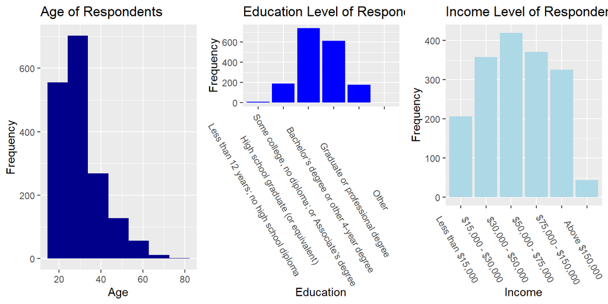

```r
# distribution of age, education, and income in our sample -- histograms
age <- ggplot(results) +
  geom_histogram(aes(x = age), bins = 7, fill = "darkblue") +
  labs( title = "Age of Respondents", x = "Age" , y = "Frequency")

education <- results %>%
      mutate(education = fct_relevel(education, "Less than 12 years; no high school diploma", "High school graduate (or equivalent)", "Some college, no diploma; or Associate’s degree", "Bachelor’s degree or other 4-year degree", "Graduate or professional degree", "Other")) %>%
  ggplot() +
  geom_histogram(aes(x = education), stat="count", fill = "blue") +
  labs(title = "Education Level of Respondents", x = "Education" , y = "Frequency") +
  theme(axis.text.x = element_text(angle = -60))

college_prop = (611+745+177)/1725

income <- results %>%
  mutate(income = fct_relevel(income, "Less than $15,000", "$15,000 - $30,000", "$30,000 - $50,000", "$50,000 - $75,000", "$75,000 - $150,000", "Above $150,000")) %>%
  ggplot() +
  geom_histogram(aes(x = income), stat="count", fill = "lightblue") +
  labs( title = "Income Level of Respondents", x = "Income" , y = "Frequency") +
  theme(axis.text.x = element_text(angle = -60))

grid.arrange(age, education, income, ncol = 3)
```

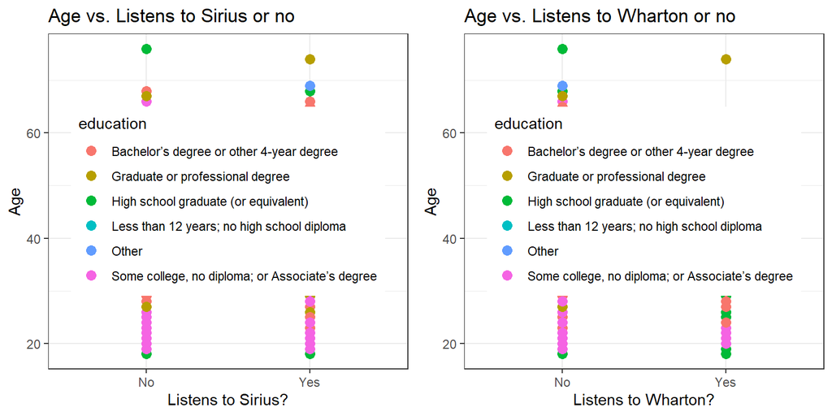

```r
# scatterplot on sirius and wharton
sirius <- results %>%
  ggplot(aes(x = sirius, y = age)) +
  # geometric options with aes mapping:
  # color, size, alpha as a function of a variable
  geom_point(aes(color = education), size = 3) +
  labs(title = "Age vs. Listens to Sirius or no",
       x = "Listens to Sirius?",
       y = "Age") +
  theme_bw() +
  theme(legend.position = c(0.5, 0.5))

wharton <- results %>%
  ggplot(aes(x = wharton, y = age)) +
  # geometric options with aes mapping:
  # color, size, alpha as a function of a variable
  geom_point(aes(color = education), size = 3) +
  labs(title = "Age vs. Listens to Wharton or no",
       x = "Listens to Wharton?",
       y = "Age") +
  theme_bw() +
  theme(legend.position = c(0.5, 0.5))

grid.arrange(sirius, wharton, ncol = 2)
```

## 2.2 Sample properties

The population from which the sample is drawn determines where the results of our analysis can be applied or generalized. We include some basic demographic information for the purpose of identifying sample bias, if any exists. Combine our data and the general population distribution in age, gender and income to try to characterize our sample on hand.

Note: You can not provide evidence by simply looking at our data here. For example, you need to find distribution of education in our age group in US to see if the two groups match in distribution. You may need to gather some background information about the MTURK population to have a slight sense if this particular sample seem to a random sample from there… Please do not spend too much time gathering evidence.

## 2.3 Final estimate

Give a final estimate of the Wharton audience size in January 2014. Assume that the sample is a random sample of the MTURK population, and that the proportion of Wharton listeners vs. Sirius listeners in the general population is the same as that in the MTURK population. Write a brief executive summary to summarize your findings and how you came to that conclusion.

To be specific, you should include:

1. Goal of the study
2. Method used: data gathering, estimation methods
3. Findings
4. Limitations of the study.

```r
#One approach is to estimate the proportion of the Wharton listeners to that of the Sirius listeners, $p$, so that we will come up with an audience size estimate of approximately 51.6 million times $p$.

wharton_prop <-
results %>%
  filter(wharton == "Yes") %>%
  nrow()

sirius_prop <-
results %>%
  filter(sirius == "Yes") %>%
  nrow()

p <- wharton_prop/sirius_prop
percent <- p*100
audience_size = 51600000 * p
```

## 2.4 New task

Now suppose you are asked to design a study to estimate the audience size of Wharton Business Radio Show as of today: You are given a budget of $1000. You need to present your findings in two months.

Write a proposal for this study which includes:

1. Method proposed to estimate the audience size.
2. What data should be collected and where it should be sourced from. Please fill in the google form to list your platform where surveys will be launched and collected [HERE](https://forms.gle/8SmjFQ1tpqr6c4sa8)

A good proposal will give an accurate estimation with the least amount of money used.

**Our new study will involve the use of multiple websites, social media platforms, or even hand-delivered mails to reach a wider and more representative audience and reduce selection bias. Such methods include websites like MTurk or SurveyMonkey or social media for the younger, educated population; and other methods include surveys through partnership with mails or newspaper for the older population. According to an article by Fit Small Business, an ad measuring four columns wide by 10 inches high in a standard newspaper would cost $480, which is more than enough space for our study and also fits within our budget. To reach the younger population, we can use multiple websites such as SurveyMonkey and Google Opinion Rewards along with Mturk, and use social media platforms such as Facebook. To increase the incentive to response on social media (since people who use social media are usually not looking to answer some surveys), we will offer raffle tickets into bigger prizes whenever they respond, which we can use around $200 for such prize.**

**As for the type of data to collect, we will use the same variables in the original survey with the addition of region and career fields to determine how representative of the US population will our sample be. Assuming we will have n participants after collecting and cleaning the data, we want to find the audience size X of Wharton. We can think of X as a random variable denoting the audience size of Wharton, and it follows a binomial distribution with probability of success p that the participants listens to Wharton. Then, p can be calculated using the original method, which is the proportion of Wharton listeners to that of Sirius listeners. We can now find the estimated audience size of Wharton, which is expectation of X from the population size of the US.**

# 3 Case study 2: Women in Science

Are women underrepresented in science in general? How does gender relate to the type of educational degree pursued? Does the number of higher degrees increase over the years? In an attempt to answer these questions, we assembled a data set (`WomenData_06_16.xlsx`) from [NSF](https://ncses.nsf.gov/pubs/nsf19304/digest/field-of-degree-women) about various degrees granted in the U.S. from 2006 to 2016. It contains the following variables: Field (Non-science-engineering (`Non-S&E`) and sciences (`Computer sciences`, `Mathematics and statistics`, etc.)), Degree (`BS`, `MS`, `PhD`), Sex (`M`, `F`), Number of degrees granted, and Year.

Our goal is to answer the above questions only through EDA (Exploratory Data Analyses) without formal testing. We have provided sample R-codes in the appendix to help you if needed.

## 3.1 Data preparation

1. Understand and clean the data

Notice the data came in as an Excel file. We need to use the package `readxl` and the function `read_excel()` to read the data `WomenData_06_16.xlsx` into R.

a). Read the data into R.

```r
women <- read_xlsx("C:/Users/nighki01/Box Sync/Course Materials/2023 Spring_Data Mining/Homework 1/data/WomenData_06_16.xlsx")
```

b). Clean the names of each variables. (Change variable names to `Field`,`Degree`, `Sex`, `Year` and `Number` )

```r
#Degree, sex, and year are already named as desired. We therefore only rename the "field and sex" and "degrees awarded" variables.
women <- women %>% rename("Field" = "Field and sex", "Number" = "Degrees Awarded")
```

c). Set the variable natures properly.

```r
#For this dataset, we would like field to be character, degree and sex to be factor, and year and number to be numeric.
str(women)
```

```
## tibble [660 × 5] (S3: tbl_df/tbl/data.frame)
##  $ Field : chr [1:660] "Agricultural sciences" "Biological sciences" "Computer sciences" "Earth, atmospheric, and ocean sciences" ...
##  $ Degree: chr [1:660] "BS" "BS" "BS" "BS" ...
##  $ Sex   : chr [1:660] "Female" "Female" "Female" "Female" ...
##  $ Year  : num [1:660] 2006 2006 2006 2006 2006 ...
##  $ Number: num [1:660] 8909 45055 9939 1646 6875 ...
```

```r
women$Degree <- as.factor(women$Degree)
women$Sex <- as.factor(women$Sex)

str(women)
```

```
## tibble [660 × 5] (S3: tbl_df/tbl/data.frame)
##  $ Field : chr [1:660] "Agricultural sciences" "Biological sciences" "Computer sciences" "Earth, atmospheric, and ocean sciences" ...
##  $ Degree: Factor w/ 3 levels "BS","MS","PhD": 1 1 1 1 1 1 1 1 1 1 ...
##  $ Sex   : Factor w/ 2 levels "Female","Male": 1 1 1 1 1 1 1 1 1 1 ...
##  $ Year  : num [1:660] 2006 2006 2006 2006 2006 ...
##  $ Number: num [1:660] 8909 45055 9939 1646 6875 ...
```

d). Any missing values? **There are no missing values in this dataset**

```r
summary(women)
```

```
##     Field           Degree        Sex           Year          Number
##  Length:660         BS :220   Female:330   Min.   :2006   Min.   :   218
##  Class :character   MS :220   Male  :330   1st Qu.:2008   1st Qu.:  2118
##  Mode  :character   PhD:220                Median :2011   Median :  6020
##                                            Mean   :2011   Mean   : 41717
##                                            3rd Qu.:2014   3rd Qu.: 18127
##                                            Max.   :2016   Max.   :781474
```

```r
colSums(is.na(women))
```

```
##  Field Degree    Sex   Year Number
##      0      0      0      0      0
```

2. Write a summary describing the data set provided here.

```r
summary(women)
```

```
##     Field           Degree        Sex           Year          Number
##  Length:660         BS :220   Female:330   Min.   :2006   Min.   :   218
##  Class :character   MS :220   Male  :330   1st Qu.:2008   1st Qu.:  2118
##  Mode  :character   PhD:220                Median :2011   Median :  6020
##                                            Mean   :2011   Mean   : 41717
##                                            3rd Qu.:2014   3rd Qu.: 18127
##                                            Max.   :2016   Max.   :781474
```

```r
table(women$Field)
```

```
##
##                  Agricultural sciences                    Biological sciences
##                                     66                                     66
##                      Computer sciences Earth, atmospheric, and ocean sciences
##                                     66                                     66
##                            Engineering             Mathematics and statistics
##                                     66                                     66
##                                Non-S&E                      Physical sciences
##                                     66                                     66
##                             Psychology                        Social sciences
##                                     66                                     66
```

```r
table(women$Year)
```

```
##
## 2006 2007 2008 2009 2010 2011 2012 2013 2014 2015 2016
##   60   60   60   60   60   60   60   60   60   60   60
```

a). How many fields are there in this data?

b). What are the degree types?

c). How many year’s statistics are being reported here?

**This is a dataset that lists the number of degrees conferred by year, sex, field, and degree type. There are five variables and 660 observations. The data includes ten fields of study, three degree types (BS, MS, and PhD), and encompasses 11 years (2006-2016, inclusive).**

## 3.2 BS degrees in 2015

Is there evidence that more males are in science-related fields vs `Non-S&E`? Provide summary statistics and a plot which shows the number of people by gender and by field. Write a brief summary to describe your findings.

**Based on our initial assessment, ignoring degree type and specific field/major, we can see that there are more females than males who obtain non-S&E degrees than males, while the two sexes are fairly even when it comes to S&E degrees. When looking at the specific field, it appears that there are more females than males who obtain degrees in biology and non- science/engineering fields as well as in psychology and social sciences. Greater numbers of males obtain degrees in computer sciences, engineering, math/statistics, and physical sciences. There seems to be somewhat equal numbers of males and females who receive degrees in agriculture and earth science.**

```r
#Grouping by field and sex, creating summary statistic that combines number of all degrees, subsetting to include only data from 2015. Creating separate subsetted dataset which combines all S&E fields.
subset_2015 <- women %>%
  group_by(Field, Sex) %>%
  mutate(all_degs = sum(Number)/10000, SE = ifelse(Field != "Non-S&E", "S&E", "Non-S&E")) %>%
  filter(Year == 2015)

subset_2015_SE <- subset_2015 %>%
  group_by(SE, Sex) %>%
  summarize(SE_number = sum(all_degs), SE)

#Summary statistics - distinct field, SE versus non-SE
subset_2015 %>% group_by(Field, Sex) %>% summarize(unique(all_degs))
```

```
## # A tibble: 20 × 3
## # Groups:   Field [10]
##    Field                                  Sex    `unique(all_degs)`
##    <chr>                                  <fct>               <dbl>
##  1 Agricultural sciences                  Female              17.3
##  2 Agricultural sciences                  Male                15.3
##  3 Biological sciences                    Female              74.5
##  4 Biological sciences                    Male                51.7
##  5 Computer sciences                      Female              17.2
##  6 Computer sciences                      Male                62.6
##  7 Earth, atmospheric, and ocean sciences Female               3.61
##  8 Earth, atmospheric, and ocean sciences Male                 5.31
##  9 Engineering                            Female              30.1
## 10 Engineering                            Male               115.
## 11 Mathematics and statistics             Female              12.5
## 12 Mathematics and statistics             Male                17.4
## 13 Non-S&E                                Female            1192.
## 14 Non-S&E                                Male               736.
## 15 Physical sciences                      Female              12.1
## 16 Physical sciences                      Male                19.4
## 17 Psychology                             Female             111.
## 18 Psychology                             Male                32.7
## 19 Social sciences                        Female             124.
## 20 Social sciences                        Male               104.
```

```r
subset_2015_SE %>% group_by(SE, Sex) %>% summarise(unique(SE_number))
```

```
## # A tibble: 4 × 3
## # Groups:   SE [2]
##   SE      Sex    `unique(SE_number)`
##   <chr>   <fct>                <dbl>
## 1 Non-S&E Female               3575.
## 2 Non-S&E Male                 2207.
## 3 S&E     Female               1208.
## 4 S&E     Male                 1270.
```

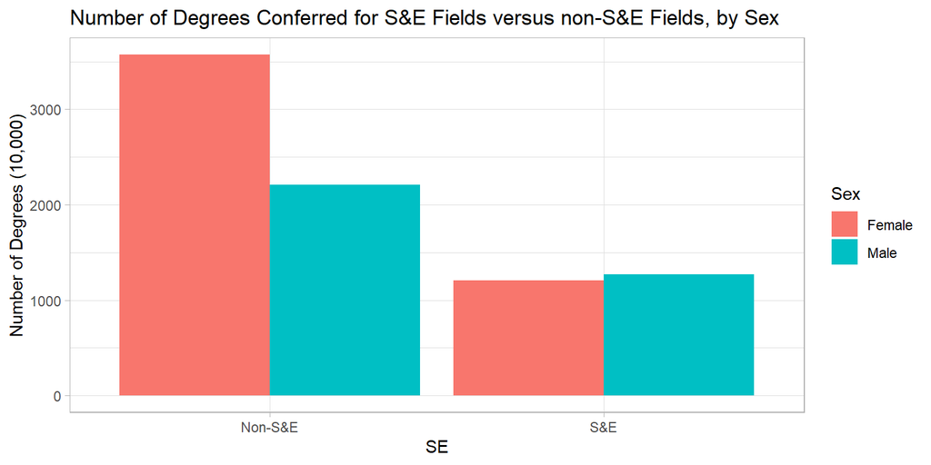

```r
#Plots
plot_2015_SE <- ggplot(subset_2015_SE, aes(x=SE, y=SE_number, fill=Sex)) +
  geom_bar(stat="identity", position="dodge") +
  scale_x_discrete(labels = function(x) str_wrap(x, width = 10)) +
  labs(y = "Number of Degrees (10,000)", title = "Number of Degrees Conferred for S&E Fields versus non-S&E Fields, by Sex") +
  theme_light()
plot_2015_SE
```

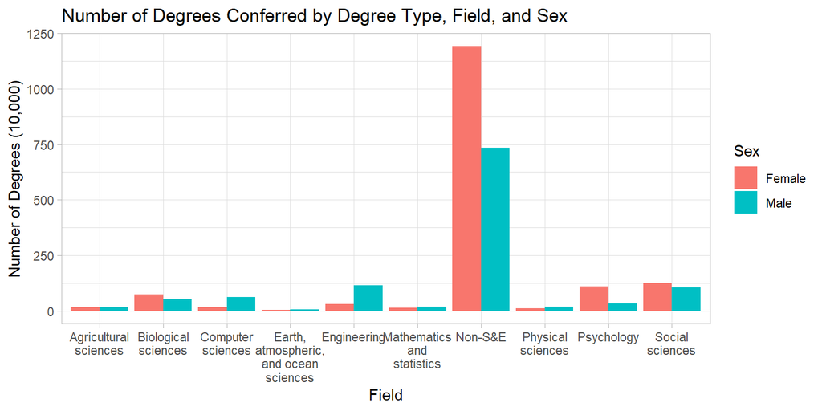

```r
plot_2015 <- ggplot(subset_2015, aes(x=Field, y=all_degs, fill=Sex)) +
  geom_bar(stat="identity", position="dodge") +
  scale_x_discrete(labels = function(x) str_wrap(x, width = 10)) +
  labs(y = "Number of Degrees (10,000)", title = "Number of Degrees Conferred by Degree Type, Field, and Sex") +
  theme_light()
plot_2015
```

## 3.3 EDA bringing type of degree, field and gender in 2015

Describe the number of people by type of degree, field, and gender. Do you see any evidence of gender effects over different types of degrees? Again, provide graphs to summarize your findings.

**Trends across degree types are easiest to observe when we consider science & engineering degrees versus non-science & engineering degrees. Across all degree types, there are more females than males who obtain degrees in non-science & engineering fields. However, whereas at the BS level the number of males and females obtaining science & engineering degrees is similar, slightly more males obtain MS degrees and even more males obtain PhD degrees compared to females.**

**As in our first assessment, a larger number of females as compared to males receive degrees in non- science/engineering fields, regardless of degree type. Notably, whereas we can now see slightly less of a difference in the number of males and females who received Bachelor’s degrees in the “hard sciences”, the difference between males and females is much more apparent when considering doctoral degrees in the “hard sciences”. As an illustration, there are approximately equal numbers of males and females who receive BS and MS degrees in Physical Sciences, but almost double the number of males receive a PhD in that field compared to females.**

```r
#Grouping by field and sex, creating summary statistic that combines number of all degrees, subsetting to include only data from 2015. Creating separate subsetted dataset which combines all S&E fields.
subset_2015_degs <- women %>%
  group_by(Field, Sex) %>%
  mutate(degree_scaled = Number/10000, SE = ifelse(Field != "Non-S&E", "S&E", "Non-S&E")) %>%
  filter(Year == 2015)

subset_2015_degs_SE <- subset_2015_degs %>%
  group_by(SE, Sex, Degree) %>%
  summarize(SE_number = sum(degree_scaled), SE, Degree)

#Summary statistics
subset_2015_degs %>% group_by(Field, Sex) %>% summarize(Degree, degree_scaled)
```

```
## # A tibble: 60 × 4
## # Groups:   Field, Sex [20]
##    Field                 Sex    Degree degree_scaled
##    <chr>                 <fct>  <fct>          <dbl>
##  1 Agricultural sciences Female BS            1.62
##  2 Agricultural sciences Female MS            0.323
##  3 Agricultural sciences Female PhD           0.0665
##  4 Agricultural sciences Male   BS            1.32
##  5 Agricultural sciences Male   MS            0.256
##  6 Agricultural sciences Male   PhD           0.0716
##  7 Biological sciences   Female BS            6.86
##  8 Biological sciences   Female MS            0.833
##  9 Biological sciences   Female PhD           0.418
## 10 Biological sciences   Male   BS            4.66
## # … with 50 more rows
```

```r
subset_2015_degs_SE %>% group_by(SE, Sex, Degree) %>% summarize(unique(SE_number))
```

```
## # A tibble: 12 × 4
## # Groups:   SE, Sex [4]
##    SE      Sex    Degree `unique(SE_number)`
##    <chr>   <fct>  <fct>                <dbl>
##  1 Non-S&E Female BS                   77.3
##  2 Non-S&E Female MS                   37.4
##  3 Non-S&E Female PhD                   1.84
##  4 Non-S&E Male   BS                   49.3
##  5 Non-S&E Male   MS                   20.9
##  6 Non-S&E Male   PhD                   1.15
##  7 S&E     Female BS                   32.3
##  8 S&E     Female MS                    8.17
##  9 S&E     Female PhD                   1.63
## 10 S&E     Male   BS                   32.7
## 11 S&E     Male   MS                    9.93
## 12 S&E     Male   PhD                   2.29
```

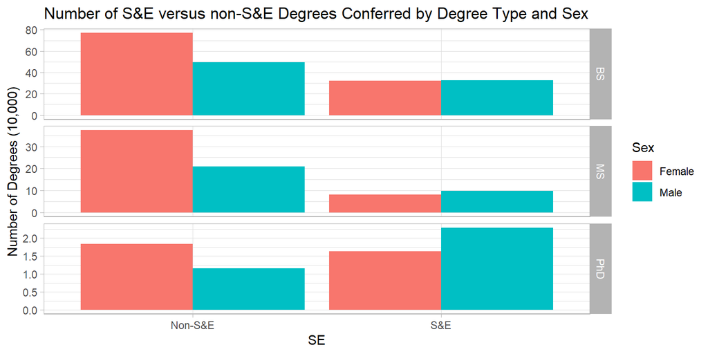

```r
#Plot
plot_2015_degs_SE <- ggplot(subset_2015_degs_SE, aes(x=SE, y=SE_number, fill=Sex)) +
  geom_bar(stat="identity", position="dodge") +
  scale_x_discrete(labels = function(x) str_wrap(x, width = 10)) +
  facet_grid(Degree~., scales = "free_y") +
  labs(y = "Number of Degrees (10,000)", title = "Number of S&E versus non-S&E Degrees Conferred by Degree Type and Sex") +
  theme_light()
plot_2015_degs_SE
```

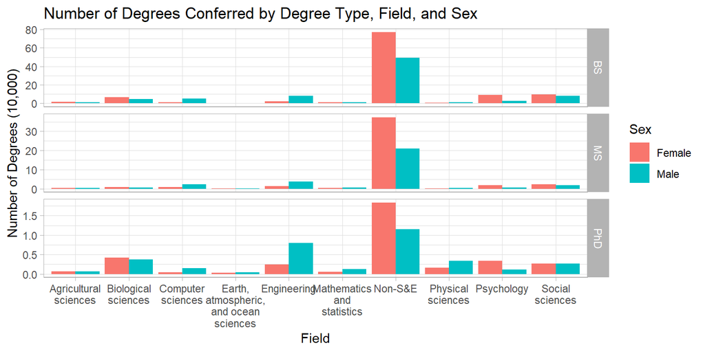

```r
plot_2015_degs <- ggplot(subset_2015_degs, aes(x=Field, y=degree_scaled, fill=Sex)) +
  geom_bar(stat="identity", position="dodge") +
  scale_x_discrete(labels = function(x) str_wrap(x, width = 10)) +
  facet_grid(Degree~., scales = "free_y") +
  labs(y = "Number of Degrees (10,000)", title = "Number of Degrees Conferred by Degree Type, Field, and Sex") +
  theme_light()
plot_2015_degs
```

## 3.4 EDA bring all variables

```r
#Proportion female in SE/non-SE fields by year
women_prop <- women %>%
  mutate(SE = ifelse(Field!="Non-S&E" , "S&E", "Non-S&E")) %>%
  group_by(SE, Sex, Year) %>%
  summarise(SE_number = sum(Number)) %>%
  group_by(SE, Year) %>%
  mutate(ratio = SE_number / sum(SE_number)) %>%
  filter(Sex == "Female")

pander(women_prop)
```

| SE | Sex | Year | SE_number | ratio |
| --- | --- | --- | --- | --- |
| Non-S&E | Female | 2006 | 946209 | 0.6191 |
| Non-S&E | Female | 2007 | 975280 | 0.6195 |
| Non-S&E | Female | 2008 | 999859 | 0.618 |
| Non-S&E | Female | 2009 | 1031410 | 0.6165 |
| Non-S&E | Female | 2010 | 1063292 | 0.616 |
| Non-S&E | Female | 2011 | 1105217 | 0.617 |
| Non-S&E | Female | 2012 | 1139689 | 0.6171 |
| Non-S&E | Female | 2013 | 1150789 | 0.6173 |
| Non-S&E | Female | 2014 | 1157693 | 0.6183 |
| Non-S&E | Female | 2015 | 1165188 | 0.6201 |
| Non-S&E | Female | 2016 | 1181698 | 0.622 |
| S&E | Female | 2006 | 307708 | 0.4882 |
| S&E | Female | 2007 | 312159 | 0.4888 |
| S&E | Female | 2008 | 320621 | 0.4888 |
| S&E | Female | 2009 | 329410 | 0.4893 |
| S&E | Female | 2010 | 341354 | 0.4891 |
| S&E | Female | 2011 | 361322 | 0.4888 |
| S&E | Female | 2012 | 385713 | 0.4905 |
| S&E | Female | 2013 | 401286 | 0.4901 |
| S&E | Female | 2014 | 412866 | 0.488 |
| S&E | Female | 2015 | 420872 | 0.4837 |
| S&E | Female | 2016 | 434609 | 0.481 |

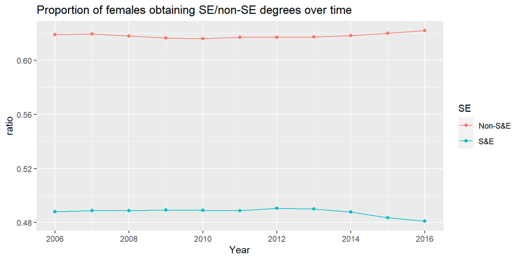

```r
plot_propf <- women_prop %>% ggplot(aes(x = Year, y = ratio, color = SE)) +
  geom_point() + geom_line() +
  ggtitle("Proportion of females obtaining SE/non-SE degrees over time")
plot_propf
```

```r
#Proportion female in SE/non-SE fields by degree and year
women_prop_deg <- women %>%
  mutate(SE = ifelse(Field!="Non-S&E" , "S&E", "Non-S&E")) %>%
  group_by(SE, Sex, Degree, Year) %>%
  summarise(SE_number = sum(Number)) %>%
  group_by(SE, Degree, Year) %>%
  mutate(ratio = SE_number / sum(SE_number)) %>%
  filter(Sex == "Female")

pander(women_prop_deg)
```

| SE | Sex | Degree | Year | SE_number | ratio |
| --- | --- | --- | --- | --- | --- |
| Non-S&E | Female | BS | 2006 | 625534 | 0.6108 |
| Non-S&E | Female | BS | 2007 | 642236 | 0.6082 |
| Non-S&E | Female | BS | 2008 | 657176 | 0.6061 |
| Non-S&E | Female | BS | 2009 | 672907 | 0.6043 |
| Non-S&E | Female | BS | 2010 | 690608 | 0.6043 |
| Non-S&E | Female | BS | 2011 | 714765 | 0.6058 |
| Non-S&E | Female | BS | 2012 | 741130 | 0.6066 |
| Non-S&E | Female | BS | 2013 | 756484 | 0.6073 |
| Non-S&E | Female | BS | 2014 | 763588 | 0.6084 |
| Non-S&E | Female | BS | 2015 | 772768 | 0.6104 |
| Non-S&E | Female | BS | 2016 | 781474 | 0.6124 |
| Non-S&E | Female | MS | 2006 | 305197 | 0.638 |
| Non-S&E | Female | MS | 2007 | 315652 | 0.6439 |
| Non-S&E | Female | MS | 2008 | 325146 | 0.6435 |
| Non-S&E | Female | MS | 2009 | 340967 | 0.6422 |
| Non-S&E | Female | MS | 2010 | 357698 | 0.6403 |
| Non-S&E | Female | MS | 2011 | 374952 | 0.6401 |
| Non-S&E | Female | MS | 2012 | 382223 | 0.639 |
| Non-S&E | Female | MS | 2013 | 377394 | 0.639 |
| Non-S&E | Female | MS | 2014 | 376469 | 0.6396 |
| Non-S&E | Female | MS | 2015 | 374024 | 0.6415 |
| Non-S&E | Female | MS | 2016 | 381074 | 0.6427 |
| Non-S&E | Female | PhD | 2006 | 15478 | 0.5986 |
| Non-S&E | Female | PhD | 2007 | 17392 | 0.6146 |
| Non-S&E | Female | PhD | 2008 | 17537 | 0.6184 |
| Non-S&E | Female | PhD | 2009 | 17536 | 0.6165 |
| Non-S&E | Female | PhD | 2010 | 14986 | 0.6053 |
| Non-S&E | Female | PhD | 2011 | 15500 | 0.6045 |
| Non-S&E | Female | PhD | 2012 | 16336 | 0.6091 |
| Non-S&E | Female | PhD | 2013 | 16911 | 0.6048 |
| Non-S&E | Female | PhD | 2014 | 17636 | 0.6155 |
| Non-S&E | Female | PhD | 2015 | 18396 | 0.6145 |
| Non-S&E | Female | PhD | 2016 | 19150 | 0.6221 |
| S&E | Female | BS | 2006 | 240829 | 0.5029 |
| S&E | Female | BS | 2007 | 244075 | 0.5024 |
| S&E | Female | BS | 2008 | 249449 | 0.5028 |
| S&E | Female | BS | 2009 | 254693 | 0.5039 |
| S&E | Female | BS | 2010 | 264283 | 0.503 |
| S&E | Female | BS | 2011 | 279107 | 0.5035 |
| S&E | Female | BS | 2012 | 297677 | 0.5049 |
| S&E | Female | BS | 2013 | 309698 | 0.5032 |
| S&E | Female | BS | 2014 | 317900 | 0.4999 |
| S&E | Female | BS | 2015 | 322935 | 0.4968 |
| S&E | Female | BS | 2016 | 330883 | 0.4967 |
| S&E | Female | MS | 2006 | 54750 | 0.4525 |
| S&E | Female | MS | 2007 | 54925 | 0.4567 |
| S&E | Female | MS | 2008 | 57594 | 0.4556 |
| S&E | Female | MS | 2009 | 61028 | 0.4537 |
| S&E | Female | MS | 2010 | 63660 | 0.455 |
| S&E | Female | MS | 2011 | 68202 | 0.4527 |
| S&E | Female | MS | 2012 | 73513 | 0.4555 |
| S&E | Female | MS | 2013 | 76351 | 0.4588 |
| S&E | Female | MS | 2014 | 78771 | 0.46 |
| S&E | Female | MS | 2015 | 81673 | 0.4513 |
| S&E | Female | MS | 2016 | 87850 | 0.443 |
| S&E | Female | PhD | 2006 | 12129 | 0.3983 |
| S&E | Female | PhD | 2007 | 13159 | 0.4038 |
| S&E | Female | PhD | 2008 | 13578 | 0.407 |
| S&E | Female | PhD | 2009 | 13689 | 0.4113 |
| S&E | Female | PhD | 2010 | 13411 | 0.4108 |
| S&E | Female | PhD | 2011 | 14013 | 0.4097 |
| S&E | Female | PhD | 2012 | 14523 | 0.4107 |
| S&E | Female | PhD | 2013 | 15237 | 0.4126 |
| S&E | Female | PhD | 2014 | 16195 | 0.4159 |
| S&E | Female | PhD | 2015 | 16264 | 0.4151 |
| S&E | Female | PhD | 2016 | 15876 | 0.4065 |

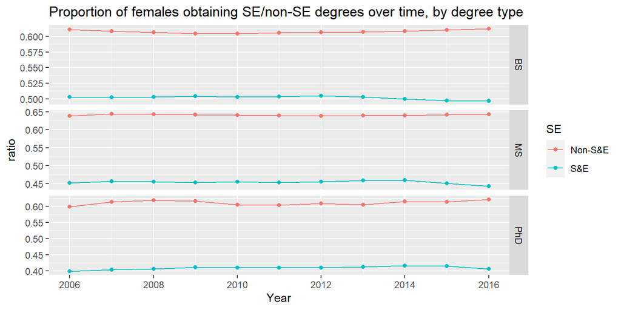

```r
plot_propf_deg <- women_prop_deg %>% ggplot(aes(x = Year, y = ratio, color = SE)) +
  geom_point() + geom_line() +
  facet_grid(Degree~., scales = "free_y") +
  ggtitle("Proportion of females obtaining SE/non-SE degrees over time, by degree type")
plot_propf_deg
```

```r
#Both sexes, SE/non-SE fields over time by degree and year. Number of degrees scaled to 10,000
women_deg <- women %>%
  mutate(SE = ifelse(Field!="Non-S&E" , "S&E", "Non-S&E"), num_scaled = Number/10000) %>%
  group_by(SE, Sex, Degree, Year) %>%
  summarise(SE_number = sum(num_scaled))

pander(women_deg)
```

| SE | Sex | Degree | Year | SE_number |
| --- | --- | --- | --- | --- |
| Non-S&E | Female | BS | 2006 | 62.55 |
| Non-S&E | Female | BS | 2007 | 64.22 |
| Non-S&E | Female | BS | 2008 | 65.72 |
| Non-S&E | Female | BS | 2009 | 67.29 |
| Non-S&E | Female | BS | 2010 | 69.06 |
| Non-S&E | Female | BS | 2011 | 71.48 |
| Non-S&E | Female | BS | 2012 | 74.11 |
| Non-S&E | Female | BS | 2013 | 75.65 |
| Non-S&E | Female | BS | 2014 | 76.36 |
| Non-S&E | Female | BS | 2015 | 77.28 |
| Non-S&E | Female | BS | 2016 | 78.15 |
| Non-S&E | Female | MS | 2006 | 30.52 |
| Non-S&E | Female | MS | 2007 | 31.57 |
| Non-S&E | Female | MS | 2008 | 32.51 |
| Non-S&E | Female | MS | 2009 | 34.1 |
| Non-S&E | Female | MS | 2010 | 35.77 |
| Non-S&E | Female | MS | 2011 | 37.5 |
| Non-S&E | Female | MS | 2012 | 38.22 |
| Non-S&E | Female | MS | 2013 | 37.74 |
| Non-S&E | Female | MS | 2014 | 37.65 |
| Non-S&E | Female | MS | 2015 | 37.4 |
| Non-S&E | Female | MS | 2016 | 38.11 |
| Non-S&E | Female | PhD | 2006 | 1.548 |
| Non-S&E | Female | PhD | 2007 | 1.739 |
| Non-S&E | Female | PhD | 2008 | 1.754 |
| Non-S&E | Female | PhD | 2009 | 1.754 |
| Non-S&E | Female | PhD | 2010 | 1.499 |
| Non-S&E | Female | PhD | 2011 | 1.55 |
| Non-S&E | Female | PhD | 2012 | 1.634 |
| Non-S&E | Female | PhD | 2013 | 1.691 |

[output cut: 102 more lines]

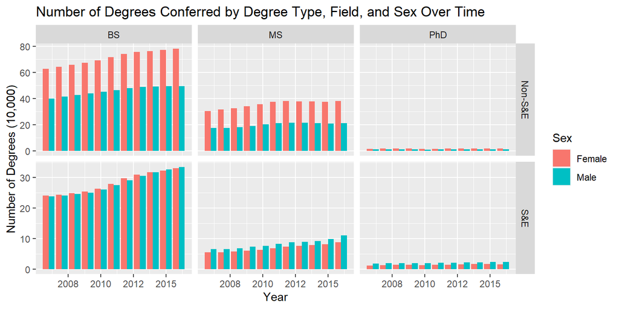

```r
plot_deg <- women_deg %>% ggplot(aes(x = Year, y = SE_number, fill = Sex)) +
  geom_bar(stat = "identity", position = "dodge") +
  facet_grid(SE~Degree, scales = "free_y") +
    labs(y = "Number of Degrees (10,000)", title = "Number of Degrees Conferred by Degree Type, Field, and Sex Over Time")
plot_deg
```

## 3.5 Women in Data Science

Finally, is there evidence showing that women are underrepresented in data science? Data science is an interdisciplinary field of computer science, math, and statistics. You may include year and/or degree.

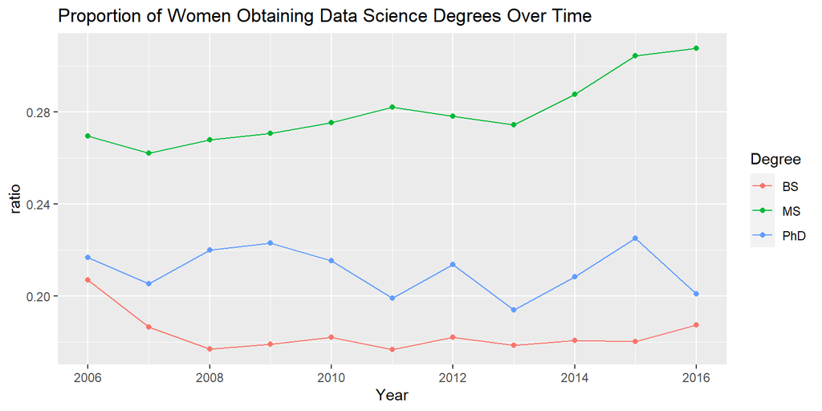

```r
#Proportion of women in data science (combines computer science and math/statistics)
women_datasci <- women %>%
  mutate(datasci = ifelse(Field == "Computer sciences", "yes", ifelse(Field == "Mathematics & statistics", "yes", "no"))) %>%
  group_by(datasci, Sex, Year, Degree) %>%
  summarise(datasci_number = sum(Number)) %>%
  group_by(datasci, Year, Degree) %>%
  mutate(ratio = datasci_number / sum(datasci_number)) %>%
  filter(Sex == "Female" & datasci == "yes")

plot_women_datasci <- women_datasci %>%
  ggplot(aes(x = Year, y = ratio, color = Degree)) +
  geom_point() + geom_line() +
  labs(title = "Proportion of Women Obtaining Data Science Degrees Over Time")
plot_women_datasci
```

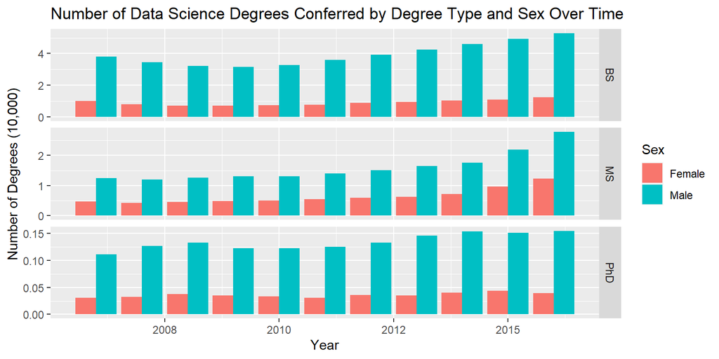

```r
#Number of degrees in data science by sex
datasci <- women %>%
    mutate(datasci = ifelse(Field == "Computer sciences", "yes", ifelse(Field == "Mathematics & statistics", "yes", "no"))) %>%
  group_by(datasci, Sex, Year, Degree) %>%
  summarise(datasci_number = sum(Number)) %>%
  group_by(datasci, Year, Degree) %>%
  mutate(ratio = datasci_number / sum(datasci_number)) %>%
  filter(datasci == "yes")

plot_datasci <- datasci %>%
  mutate(datasci_scaled = datasci_number/10000) %>%
  ggplot(aes(x = Year, y = datasci_scaled, fill = Sex)) +
    geom_bar(stat = "identity", position = "dodge") +
  facet_grid(Degree~., scales = "free_y") +
    labs(y = "Number of Degrees (10,000)", title = "Number of Data Science Degrees Conferred by Degree Type and Sex Over Time")
plot_datasci
```

## 3.6 Final brief report

Summarize your findings focusing on answering the questions regarding if we see consistent patterns that more males pursue science-related fields. Any concerns with the data set? How could we improve on the study?

**One potential concern with the data set is that it is limited to BS, MS, and PhD degrees - it is possible that inclusion of other degree types (such as BA and MA) could impact the results. It could also be of interest to incorporate career information, as receipt of a science/engineering degree does not necessarily mean the individual ended up working in that field (and vice-versa). Finally, it would be helpful to further specify the research question to specific fields, or better define what fields count as “science”, as we can see when looking at individual fields that trends are not consistent across fields.**

# 4 Case study 3: Major League Baseball

We would like to explore how payroll affects performance among Major League Baseball teams. The data is prepared in two formats record payroll, winning numbers/percentage by team from 1998 to 2014.

Here are the datasets:

-`MLPayData_Total.csv`: wide format -`baseball.csv`: long format

Feel free to use either dataset to address the problems.

## 4.1 EDA: Relationship between payroll changes and performance

Payroll may relate to performance among ML Baseball teams. One possible argument is that what affects this year’s performance is not this year’s payroll, but the amount that payroll increased from last year. Let us look into this through EDA.

Create increment in payroll

a). To describe the increment of payroll in each year there are several possible approaches. Take 2013 as an example:

```
- option 1: diff: payroll_2013 - payroll_2012
- option 2: log diff: log(payroll_2013) - log(payroll_2012)
```

Explain why the log difference is more appropriate in this setup.

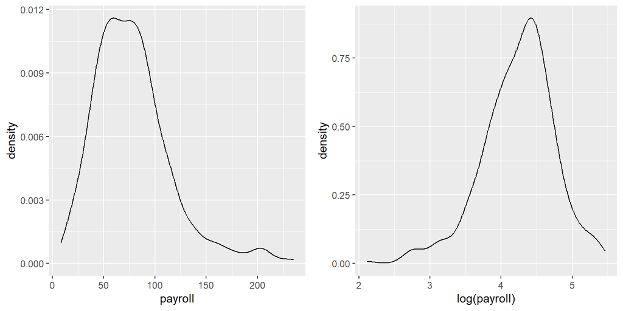

**1. As the density plot shown, the variable payroll is right skewed. After the log transformation, the density plot is much less skewed. Therefore, it is more appropriate to use log difference.**

**2. Because of the mathematical properties of logarithm: $log(a)-log(b)=log(\frac{a}{b})$, the logarithm transformation converts absolute difference into relative difference.**

b). Create a new variable `diff_log=log(payroll_2013) - log(payroll_2012)`. Hint: use `dplyr::lag()` function.

```
## # A tibble: 6 × 6
## # Groups:   team [1]
##   team                  year payroll win_num win_pct diff_log
##   <chr>                <int>   <dbl>   <int>   <dbl>    <dbl>
## 1 Arizona Diamondbacks  1998    31.6      65   0.401 NA
## 2 Arizona Diamondbacks  1999    70.5     100   0.617  0.802
## 3 Arizona Diamondbacks  2000    81.0      85   0.525  0.139
## 4 Arizona Diamondbacks  2001    81.2      92   0.568  0.00220
## 5 Arizona Diamondbacks  2002   103.       98   0.605  0.236
## 6 Arizona Diamondbacks  2003    80.6      84   0.519 -0.243
```

c). Create a long data table including: team, year, diff_log, win_pct

```
## # A tibble: 6 × 4
## # Groups:   team [1]
##   team                  year diff_log win_pct
##   <chr>                <int>    <dbl>   <dbl>
## 1 Arizona Diamondbacks  1998 NA         0.401
## 2 Arizona Diamondbacks  1999  0.802     0.617
## 3 Arizona Diamondbacks  2000  0.139     0.525
## 4 Arizona Diamondbacks  2001  0.00220   0.568
## 5 Arizona Diamondbacks  2002  0.236     0.605
## 6 Arizona Diamondbacks  2003 -0.243     0.519
```

## 4.2 Exploratory questions

a). Which five teams had highest increase in their payroll between years 2010 and 2014, inclusive?

```
## # A tibble: 6 × 2
##   team                 diff_sum
##   <chr>                   <dbl>
## 1 Los Angeles Dodgers     0.851
## 2 Washington Nationals    0.820
## 3 San Diego Padres        0.744
## 4 Texas Rangers           0.684
## 5 San Francisco Giants    0.629
## 6 Toronto Blue Jays       0.493
```

**Los Angeles Dodgers, Washington Nationals, San Diego Padres, Texas Rangers and San Francisco Giants had highest increase in their payroll between years 2010 and 2014.**

b). Between 2010 and 2014, inclusive, which team(s) “improved” the most? That is, had the biggest percentage gain in wins?

```
## # A tibble: 6 × 4
## # Groups:   team [6]
##   team                 X2014.pct X2010.pct   pct
##   <chr>                    <dbl>     <dbl> <dbl>
## 1 Pittsburgh Pirates       0.543     0.352 0.191
## 2 Baltimore Orioles        0.593     0.407 0.185
## 3 Washington Nationals     0.593     0.426 0.167
## 4 Seattle Mariners         0.537     0.377 0.160
## 5 Kansas City Royals       0.549     0.414 0.136
## 6 Los Angeles Angels       0.605     0.494 0.111
```

**Pittsburgh Pirates had the biggest percentage gain in wins between 2010 and 2014.**

## 4.3 Do log increases in payroll imply better performance?

Is there evidence to support the hypothesis that higher increases in payroll on the log scale lead to increased performance?

Pick up a few statistics, accompanied with some data visualization, to support your answer.

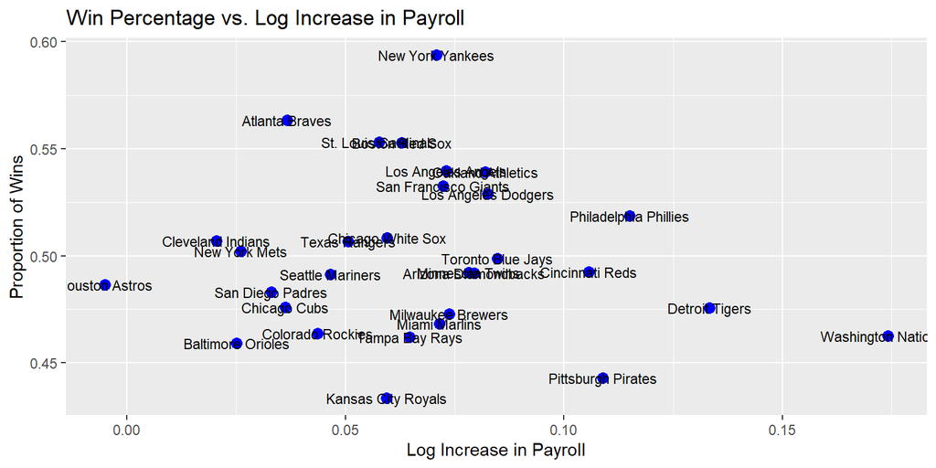

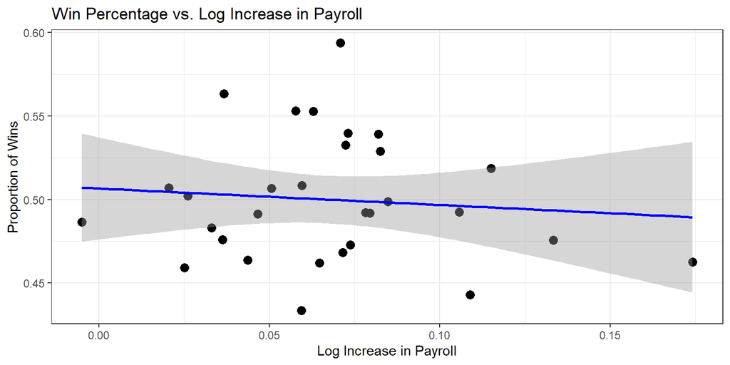

**No, there is no strong evidence to support the hypothesis that higher increases in payroll on the log scale lead to increased performance.**

**In the scatter plot, the data points do not cluster tightly.**

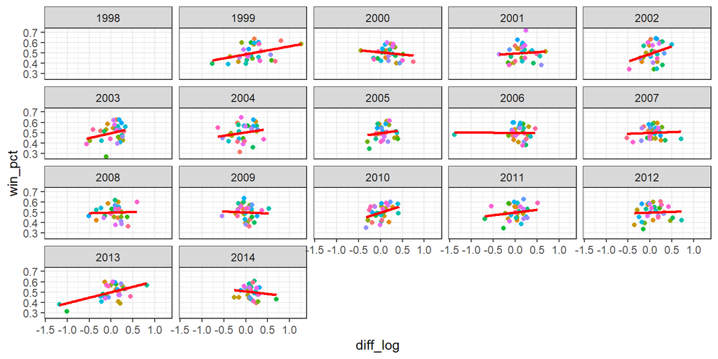

**The plot indicates that log increases in payroll and performance is not consistently positively related in some years.**

```
##
## Call:
## lm(formula = win_pct_mean ~ payroll_mean, data = data_final)
##
## Residuals:
##      Min       1Q   Median       3Q      Max
## -0.06728 -0.02686 -0.00524  0.02863  0.09416
##
## Coefficients:
##              Estimate Std. Error t value Pr(>|t|)
## (Intercept)    0.5066     0.0149    33.9   <2e-16 ***
## payroll_mean  -0.0985     0.1959    -0.5     0.62
## ---
## Signif. codes:  0 '***' 0.001 '**' 0.01 '*' 0.05 '.' 0.1 ' ' 1
##
## Residual standard error: 0.0381 on 28 degrees of freedom
## Multiple R-squared:  0.00894,    Adjusted R-squared:  -0.0265
## F-statistic: 0.253 on 1 and 28 DF,  p-value: 0.619
```

```
##
## Call:
## lm(formula = win_pct ~ diff_log + year + year * diff_log, data = datapay_long)
##
## Residuals:
##      Min       1Q   Median       3Q      Max
## -0.22532 -0.05369  0.00232  0.05349  0.20884
##
## Coefficients:
##                Estimate Std. Error t value Pr(>|t|)
## (Intercept)    3.84e-02   1.49e+00    0.03     0.98
## diff_log      -1.12e-01   5.04e+00   -0.02     0.98
## year           2.28e-04   7.42e-04    0.31     0.76
## diff_log:year  7.91e-05   2.51e-03    0.03     0.97
##
## Residual standard error: 0.0704 on 476 degrees of freedom
##   (30 observations deleted due to missingness)
## Multiple R-squared:  0.0281, Adjusted R-squared:  0.022
## F-statistic: 4.59 on 3 and 476 DF,  p-value: 0.0035
```

```
## [1] -0.0946
```

**R-squared in the linear model for average win percentage and average log increases in payroll is relatively small, showing the linear regression model did not fit the data well and there was no strong linear relationship between log increases in payroll and win percentage. Same for the linear regression model when considering year and interaction between year and log increases in payroll.**

**The correlation coefficient is -0.0946, indicating a low correlation.**

## 4.4 Comparison

Which set of factors are better explaining performance? Yearly payroll or yearly increase in payroll? What criterion is being used?

**I think yearly increase in payroll can better explaining performance, because the baseline payroll for each team is different. For instance, there is one team got relatively low payroll in the previous year, and the payroll increased greatly for this team in the next year. The overall yearly payroll for this team is still not as high as another team who got high payroll in the previous year though less increment in the next year. The relative increase is better to analyze the performance of one team.**